# Separate Admixture analysis

Mar Llaberia-Robledillo

16/6/2022

# Alpine and Arctic species

#### Removing species with less than 10 individuals/samples

```r
poptable <- read.table('~/cophyhopa/data/popmap.txt',
                       col.names = c('sample', 'group', 'pop', 'lake'))

poptable <- poptable[-which(poptable[,3] == "C.alpinus"), ]
poptable <- poptable[-which(poptable[,3] == "C.alpinus/C.steinmanni"), ]
poptable <- poptable[-which(poptable[,3] == "C.brienzii"), ]
poptable <- poptable[-which(poptable[,3] == "C.fatioi/C.albellus"), ]
poptable <- poptable[-which(poptable[,3] == "C.brienzii/C.fatioi"), ]

write.table(poptable[,1], file = '~/cophyhopa/results/2022-05-09/admixture/ALL.txt', quote = FALSE,
            row.names = FALSE, col.names = FALSE)
```

#### Data selecting and filtering

```bash
VCF='/gata/mar/cophyhopa/results/2022-04-22/assem2_outfiles/assem2.vcf'
FILE=ALL
if [ ! -e $FILE.vcf.gz ]; then
   vcftools --vcf $VCF \
            --out dirty \
            --keep ALL.txt \
            --remove ~/cophyhopa/results/2022-05-04/TheWorst.txt \
            --recode \
            --recode-INFO-all
   vcftools --vcf dirty.recode.vcf \
            --out $FILE \
            --thin 500 \
            --remove-indels \
            --mac 2 \
            --max-alleles 2 \
            --max-meanDP 1000 \
            --max-missing-count 7 \
            --stdout \
            --recode --recode-INFO-all \
            | gzip > $FILE.vcf.gz
fi
if [ -e dirty.recode.vcf ]; then rm dirty.recode.vcf; fi

if [ ! -e chromMap.txt ]; then
   gunzip -c $FILE".vcf.gz" | \
   gawk '(/^[^#]/){
      A[$1] = 1
   }END{
      N = 1
      for (chr in A) {
         print chr "\t" N
         N = N + 1
      }
   }' > chromMap.txt
fi

vcftools --gzvcf $FILE".vcf.gz" \
         --plink --mac 2 --remove-indels --max-alleles 2 \
         --chrom-map chromMap.txt \
         --out $FILE

gawk -v OFS="\t" '{
   $1 = 1
   $2 = 1 ":" $4
   print $0
}' $FILE".map" > better.map
mv better.map $FILE.map

plink --file $FILE --make-bed --out $FILE --allow-no-sex --allow-extra-chr 0
```

#### Admixture analysis with variant K

We define the K parameter from 7 to 11, computing the cross-validation error. Then, we extract these values.

```bash
INPUT='/gata/mar/cophyhopa/results/2022-05-09/admixture/ALL.bed'

for K in 7 8 9 10 11; do
  if [ ! -e log${K}.ALL.out ]; then
    admixture --cv $INPUT $K | tee log${K}.ALL.out;
  fi
done
```

```bash
grep -h CV log*.ALL.out
```

```
## CV error (K=10): 0.24114
## CV error (K=11): 0.24399
## CV error (K=7): 0.23764
## CV error (K=8): 0.23902
## CV error (K=9): 0.24095
```

We choose the K that has given a lower value of the cross-validation error. We add the sample names and display a barplot

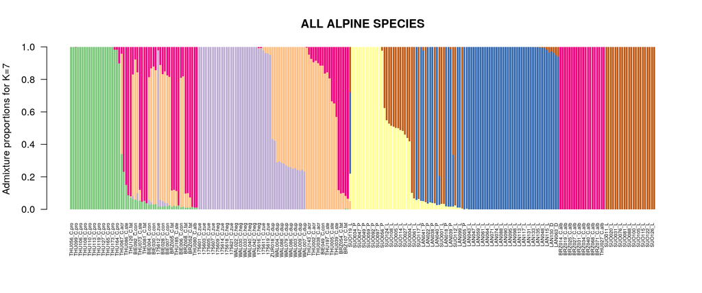

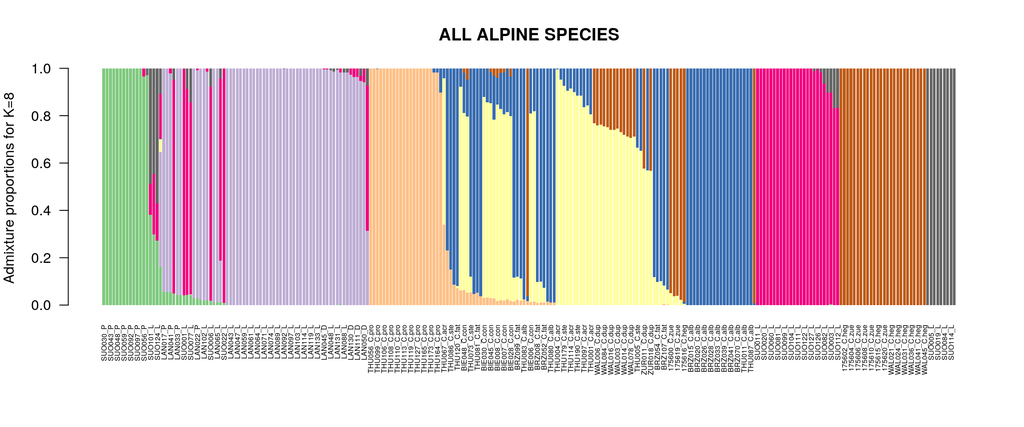

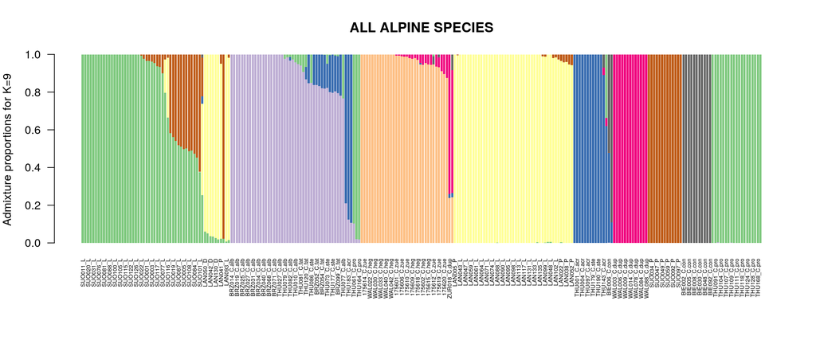

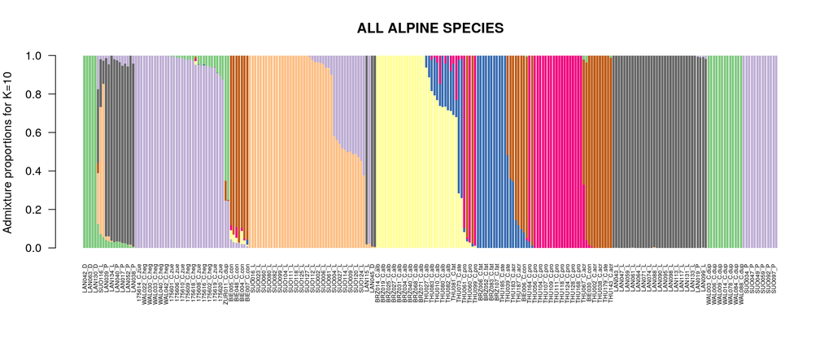

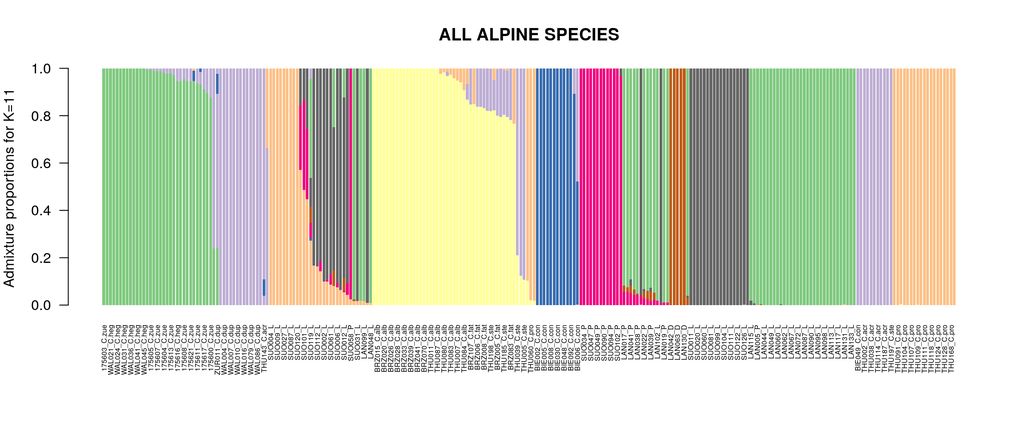

# Species in Alpine lakes

## Lakes Walen and Zurichesse

### Data selecting and filtering

```bash
VCF='/gata/mar/cophyhopa/results/2022-04-22/assem2_outfiles/assem2.vcf'
FILE=WZ
if [ ! -e $FILE.vcf.gz ]; then
   vcftools --vcf $VCF \
            --out dirty \
            --keep ~/cophyhopa/data/Walen.txt \
            --keep ~/cophyhopa/data/Zurich.txt \
            --remove ~/cophyhopa/results/2022-05-04/TheWorst.txt \
            --recode \
            --recode-INFO-all
   vcftools --vcf dirty.recode.vcf \
            --out $FILE \
            --thin 500 \
            --remove-indels \
            --mac 2 \
            --max-alleles 2 \
            --max-meanDP 1000 \
            --max-missing-count 7 \
            --stdout \
            --recode --recode-INFO-all \
            | gzip > $FILE.vcf.gz
fi
if [ -e dirty.recode.vcf ]; then rm dirty.recode.vcf; fi

if [ ! -e chromMap.txt ]; then
   gunzip -c $FILE".vcf.gz" | \
   gawk '(/^[^#]/){
      A[$1] = 1
   }END{
      N = 1
      for (chr in A) {
         print chr "\t" N
         N = N + 1
      }
   }' > chromMap.txt
fi

vcftools --gzvcf $FILE".vcf.gz" \
         --plink --mac 2 --remove-indels --max-alleles 2 \
         --chrom-map chromMap.txt \
         --out $FILE

gawk -v OFS="\t" '{
   $1 = 1
   $2 = 1 ":" $4
   print $0
}' $FILE".map" > better.map
mv better.map $FILE.map

plink --file $FILE --make-bed --out $FILE --allow-no-sex --allow-extra-chr 0
```

### Admixture analysis with variant K

We define the K parameter from 2 to 4, computing the cross-validation error. Then, we extract these values.

```bash
INPUT='/gata/mar/cophyhopa/results/2022-05-09/admixture/WZ.bed'

for K in 2 3 4; do
  if [ ! -e log${K}.WZ.out ]; then
    admixture --cv $INPUT $K | tee log${K}.WZ.out;
  fi
done
```

```bash
grep -h CV log*.WZ.out
```

```
## CV error (K=2): 0.48759
## CV error (K=3): 0.53744
## CV error (K=4): 0.66391
```

### Plot Q estimates for K = 2, 3 and 4

We choose the K that has given a lower value of the cross-validation error. We add the sample names and display a barplot

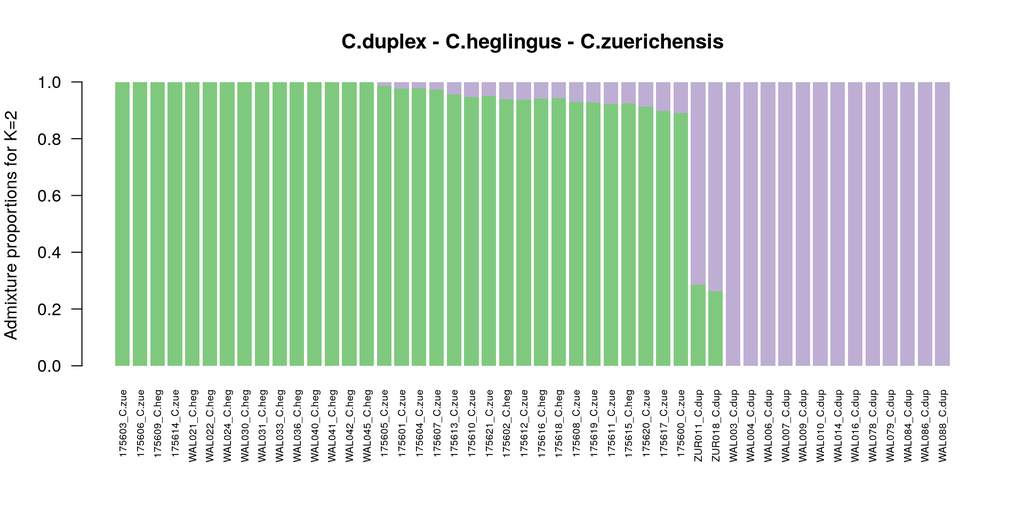

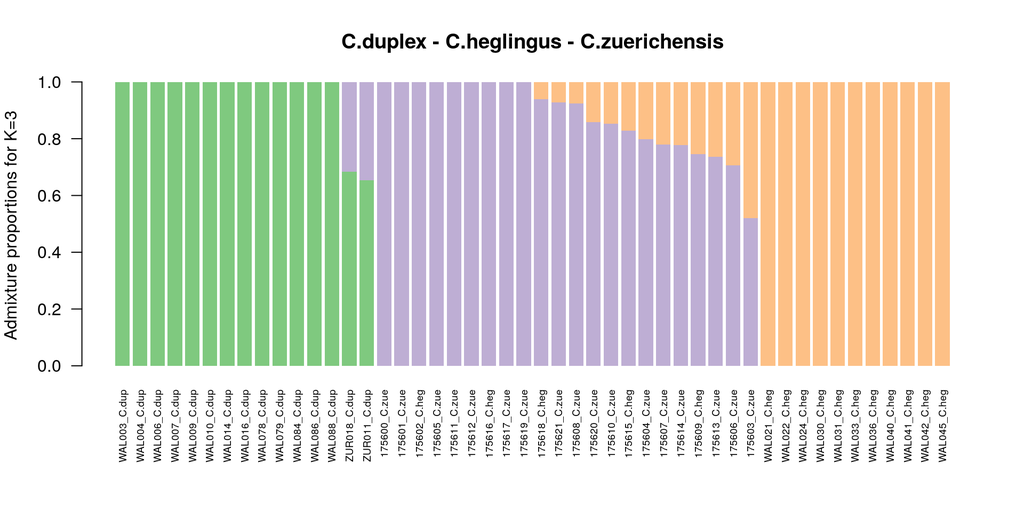

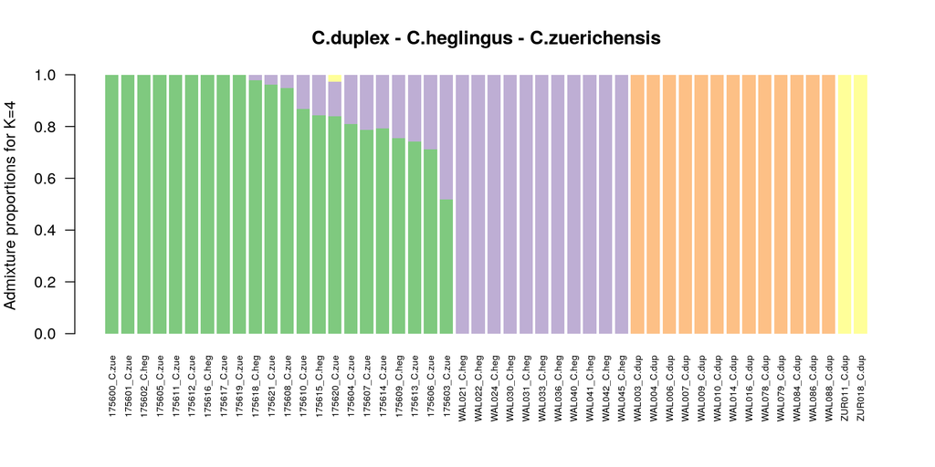

## Lakes Brienz and Thun

### All species

#### Removing species with less than 10 individuals/samples

Additionally, keep only those species that are present in lakes Brienz and Thun.

```r
poptable <- read.table('~/cophyhopa/data/popmap.txt',
                       col.names = c('sample', 'group', 'pop', 'lake'))

poptable <- poptable[-which(poptable[,3] == "C.alpinus"), ]
poptable <- poptable[-which(poptable[,3] == "C.alpinus/C.steinmanni"), ]
poptable <- poptable[-which(poptable[,3] == "C.brienzii"), ]
poptable <- poptable[-which(poptable[,3] == "C.fatioi/C.albellus"), ]
poptable <- poptable[-which(poptable[,3] == "D"), ]
poptable <- poptable[-which(poptable[,3] == "L"), ]
poptable <- poptable[-which(poptable[,3] == "P"), ]
poptable <- poptable[-which(poptable[,3] == "C.duplex"), ]
poptable <- poptable[-which(poptable[,3] == "C.heglingus"), ]
poptable <- poptable[-which(poptable[,3] == "C.zuerichensis"), ]
poptable <- poptable[-which(poptable[,3] == "C.confusus"), ]
poptable <- poptable[-which(poptable[,3] == "C.brienzii/C.fatioi"), ]

write.table(poptable[,1], file = '~/cophyhopa/results/2022-05-09/admixture/BT_all.txt', quote = FALSE,
            row.names = FALSE, col.names = FALSE)
```

#### Data selecting and filtering

```bash
VCF='/gata/mar/cophyhopa/results/2022-04-22/assem2_outfiles/assem2.vcf'
FILE=BT_all
if [ ! -e $FILE.vcf.gz ]; then
   vcftools --vcf $VCF \
            --out dirty \
            --keep BT_all.txt \
            --remove ~/cophyhopa/results/2022-05-04/TheWorst.txt \
            --recode \
            --recode-INFO-all
   vcftools --vcf dirty.recode.vcf \
            --out $FILE \
            --thin 500 \
            --remove-indels \
            --mac 2 \
            --max-alleles 2 \
            --max-meanDP 1000 \
            --max-missing-count 7 \
            --stdout \
            --recode --recode-INFO-all \
            | gzip > $FILE.vcf.gz
fi
if [ -e dirty.recode.vcf ]; then rm dirty.recode.vcf; fi

if [ ! -e chromMap.txt ]; then
   gunzip -c $FILE".vcf.gz" | \
   gawk '(/^[^#]/){
      A[$1] = 1
   }END{
      N = 1
      for (chr in A) {
         print chr "\t" N
         N = N + 1
      }
   }' > chromMap.txt
fi

vcftools --gzvcf $FILE".vcf.gz" \
         --plink --mac 2 --remove-indels --max-alleles 2 \
         --chrom-map chromMap.txt \
         --out $FILE

gawk -v OFS="\t" '{
   $1 = 1
   $2 = 1 ":" $4
   print $0
}' $FILE".map" > better.map
mv better.map $FILE.map

plink --file $FILE --make-bed --out $FILE --allow-no-sex --allow-extra-chr 0
```

#### Admixture analysis with variant K

We define the K parameter from 4 to 6, computing the cross-validation error. Then, we extract these values.

```bash
INPUT='/gata/mar/cophyhopa/results/2022-05-09/admixture/BT_all.bed'

for K in 4 5 6; do
  if [ ! -e log${K}.BT_all.out ]; then
    admixture --cv $INPUT $K | tee log${K}.BT_all.out;
  fi
done
```

```bash
grep -h CV log*.BT_all.out
```

```
## CV error (K=4): 0.43703
## CV error (K=5): 0.46533
## CV error (K=6): 0.50438
```

#### Plot Q estimates for K = 4, 5 and 6

We choose the K that has given a lower value of the cross-validation error. We add the sample names and display a barplot

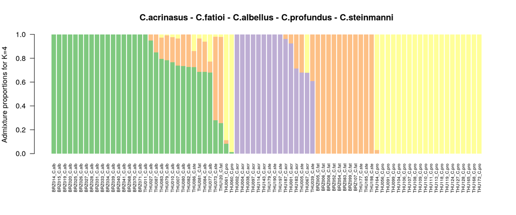

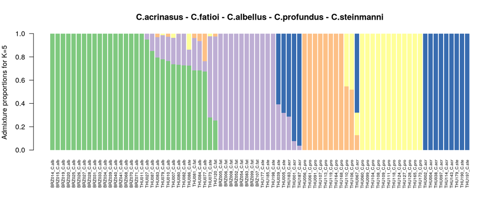

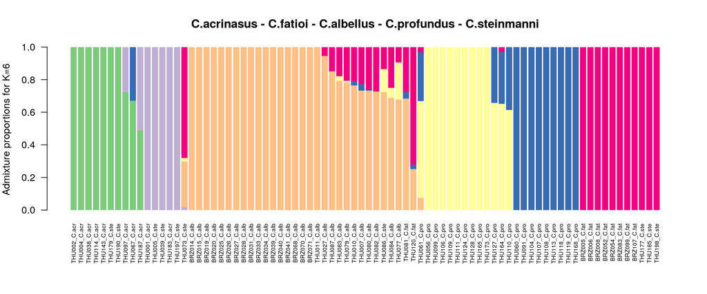

### C.acrinasus - C.fatioi - C.albellus - C.profundus

We exclude C.steinmanni because it seems to have the more confuse association in clusters.

#### Removing species with less than 10 individuals/samples

Additionally, keep only those species that are present in lakes Brienz and Thun.

```r
poptable <- read.table('~/cophyhopa/data/popmap.txt',
                       col.names = c('sample', 'group', 'pop', 'lake'))

poptable <- poptable[-which(poptable[,3] == "C.alpinus"), ]
poptable <- poptable[-which(poptable[,3] == "C.alpinus/C.steinmanni"), ]
poptable <- poptable[-which(poptable[,3] == "C.brienzii"), ]
poptable <- poptable[-which(poptable[,3] == "C.fatioi/C.albellus"), ]
poptable <- poptable[-which(poptable[,3] == "D"), ]
poptable <- poptable[-which(poptable[,3] == "L"), ]
poptable <- poptable[-which(poptable[,3] == "P"), ]
poptable <- poptable[-which(poptable[,3] == "C.duplex"), ]
poptable <- poptable[-which(poptable[,3] == "C.heglingus"), ]
poptable <- poptable[-which(poptable[,3] == "C.zuerichensis"), ]
poptable <- poptable[-which(poptable[,3] == "C.confusus"), ]
poptable <- poptable[-which(poptable[,3] == "C.brienzii/C.fatioi"), ]
poptable <- poptable[-which(poptable[,3] == "C.steinmanni"), ]

write.table(poptable[,1], file = '~/cophyhopa/results/2022-05-09/admixture/BT_afap.txt', quote = FALSE,
            row.names = FALSE, col.names = FALSE)
```

#### Data selecting and filtering

```bash
VCF='/gata/mar/cophyhopa/results/2022-04-22/assem2_outfiles/assem2.vcf'
FILE=BT_afap
if [ ! -e $FILE.vcf.gz ]; then
   vcftools --vcf $VCF \
            --out dirty \
            --remove ~/cophyhopa/results/2022-05-04/TheWorst.txt \
            --keep BT_afap.txt \
            --recode \
            --recode-INFO-all
   vcftools --vcf dirty.recode.vcf \
            --out $FILE \
            --thin 500 \
            --remove-indels \
            --mac 2 \
            --max-alleles 2 \
            --max-meanDP 1000 \
            --max-missing-count 7 \
            --stdout \
            --recode --recode-INFO-all \
            | gzip > $FILE.vcf.gz
fi
if [ -e dirty.recode.vcf ]; then rm dirty.recode.vcf; fi

if [ ! -e chromMap.txt ]; then
   gunzip -c $FILE".vcf.gz" | \
   gawk '(/^[^#]/){
      A[$1] = 1
   }END{
      N = 1
      for (chr in A) {
         print chr "\t" N
         N = N + 1
      }
   }' > chromMap.txt
fi

vcftools --gzvcf $FILE".vcf.gz" \
         --plink --mac 2 --remove-indels --max-alleles 2 \
         --chrom-map chromMap.txt \
         --out $FILE

gawk -v OFS="\t" '{
   $1 = 1
   $2 = 1 ":" $4
   print $0
}' $FILE".map" > better.map
mv better.map $FILE.map

plink --file $FILE --make-bed --out $FILE --allow-no-sex --allow-extra-chr 0
```

#### Admixture analysis with variant K

We define the K parameter from 3 to 5, computing the cross-validation error. Then, we extract these values.

```bash
INPUT='/gata/mar/cophyhopa/results/2022-05-09/admixture/BT_afap.bed'

for K in 3 4 5; do
  if [ ! -e log${K}.BT_afap.out ]; then
    admixture --cv $INPUT $K | tee log${K}.BT_afap.out;
  fi
done
```

```bash
grep -h CV log*.BT_afap.out
```

```
## CV error (K=3): 0.44847
## CV error (K=4): 0.46925
## CV error (K=5): 0.49890
```

#### Plot Q estimates for K = 3, 4 and 5

We choose the K that has given a lower value of the cross-validation error. We add the sample names and display a barplot

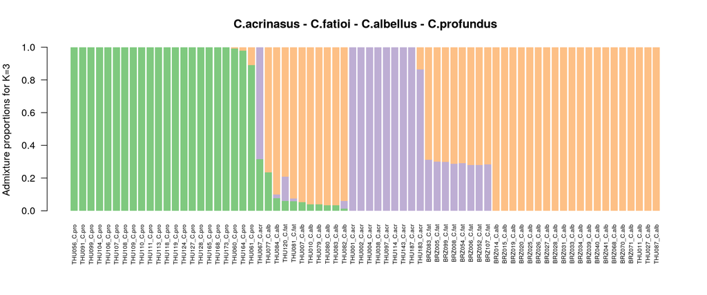

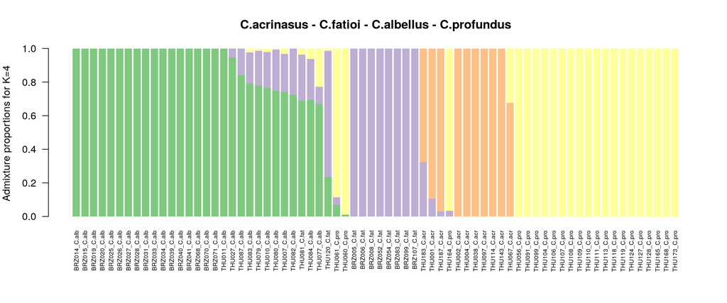

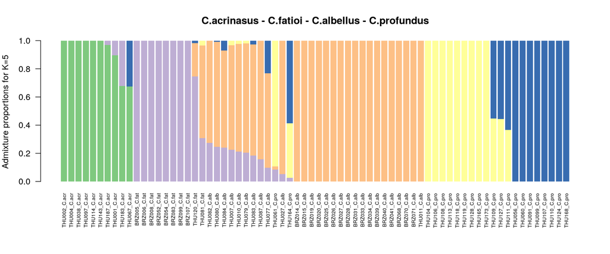

### C.acrinasus - C.fatioi - C.albellus

We exclude C.profundus because it seems to be a clearly cluster itself.

#### Removing species with less than 10 individuals/samples

Additionally, keep only those species that are present in lakes Brienz and Thun.

```r
poptable <- read.table('~/cophyhopa/data/popmap.txt',
                       col.names = c('sample', 'group', 'pop', 'lake'))

poptable <- poptable[-which(poptable[,3] == "C.alpinus"), ]
poptable <- poptable[-which(poptable[,3] == "C.alpinus/C.steinmanni"), ]
poptable <- poptable[-which(poptable[,3] == "C.brienzii"), ]
poptable <- poptable[-which(poptable[,3] == "C.fatioi/C.albellus"), ]
poptable <- poptable[-which(poptable[,3] == "D"), ]
poptable <- poptable[-which(poptable[,3] == "L"), ]
poptable <- poptable[-which(poptable[,3] == "P"), ]
poptable <- poptable[-which(poptable[,3] == "C.duplex"), ]
poptable <- poptable[-which(poptable[,3] == "C.heglingus"), ]
poptable <- poptable[-which(poptable[,3] == "C.zuerichensis"), ]
poptable <- poptable[-which(poptable[,3] == "C.confusus"), ]
poptable <- poptable[-which(poptable[,3] == "C.brienzii/C.fatioi"), ]

poptable <- poptable[-which(poptable[,3] == "C.steinmanni"), ]
poptable <- poptable[-which(poptable[,3] == "C.profundus"), ]

write.table(poptable[,1], file = '~/cophyhopa/results/2022-05-09/admixture/BT_afa.txt', quote = FALSE,
            row.names = FALSE, col.names = FALSE)
```

#### Data selecting and filtering

```bash
VCF='/gata/mar/cophyhopa/results/2022-04-22/assem2_outfiles/assem2.vcf'
FILE=BT_afa
if [ ! -e $FILE.vcf.gz ]; then
   vcftools --vcf $VCF \
            --out dirty \
            --keep BT_afa.txt \
            --remove ~/cophyhopa/results/2022-05-04/TheWorst.txt \
            --recode \
            --recode-INFO-all
   vcftools --vcf dirty.recode.vcf \
            --out $FILE \
            --thin 500 \
            --remove-indels \
            --mac 2 \
            --max-alleles 2 \
            --max-meanDP 1000 \
            --max-missing-count 7 \
            --stdout \
            --recode --recode-INFO-all \
            | gzip > $FILE.vcf.gz
fi
if [ -e dirty.recode.vcf ]; then rm dirty.recode.vcf; fi

if [ ! -e chromMap.txt ]; then
   gunzip -c $FILE".vcf.gz" | \
   gawk '(/^[^#]/){
      A[$1] = 1
   }END{
      N = 1
      for (chr in A) {
         print chr "\t" N
         N = N + 1
      }
   }' > chromMap.txt
fi

vcftools --gzvcf $FILE".vcf.gz" \
         --plink --mac 2 --remove-indels --max-alleles 2 \
         --chrom-map chromMap.txt \
         --out $FILE

gawk -v OFS="\t" '{
   $1 = 1
   $2 = 1 ":" $4
   print $0
}' $FILE".map" > better.map
mv better.map $FILE.map

plink --file $FILE --make-bed --out $FILE --allow-no-sex --allow-extra-chr 0
```

#### Admixture analysis with variant K

We define the K parameter from 2 to 4, computing the cross-validation error. Then, we extract these values.

```bash
INPUT='/gata/mar/cophyhopa/results/2022-05-09/admixture/BT_afa.bed'

for K in 2 3 4; do
  if [ ! -e log${K}.BT_afa.out ]; then
    admixture --cv $INPUT $K | tee log${K}.BT_afa.out;
  fi
done
```

```bash
grep -h CV log*.BT_afa.out
```

```
## CV error (K=2): 0.50060
## CV error (K=3): 0.53476
## CV error (K=4): 0.62421
```

#### Plot Q estimates for K = 2, 3 and 4

We choose the K that has given a lower value of the cross-validation error. We add the sample names and display a barplot.

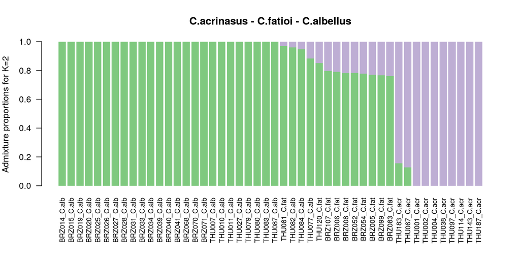

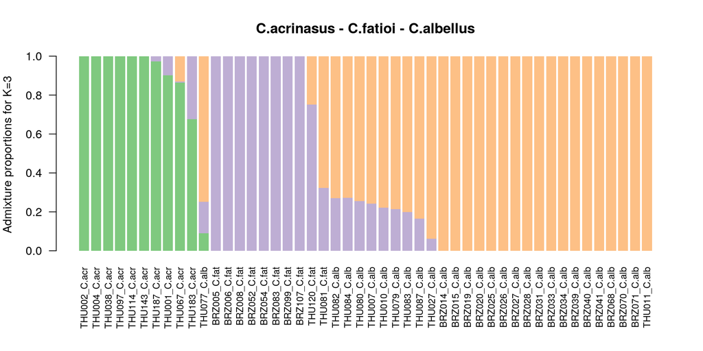

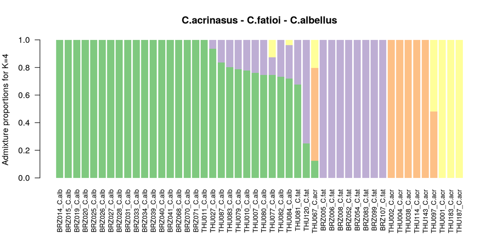

### C.fatioi - C.albellus

Now, we exclude C.acrinasus because it seems to be confused with C.albellus. We gonna exclude those 2 species to observe the classification without one or the other.

#### Removing species with less than 10 individuals/samples

Additionally, keep only those species that are present in lakes Brienz and Thun.

```r
poptable <- read.table('~/cophyhopa/data/popmap.txt',
                       col.names = c('sample', 'group', 'pop', 'lake'))

poptable <- poptable[-which(poptable[,3] == "C.alpinus"), ]
poptable <- poptable[-which(poptable[,3] == "C.alpinus/C.steinmanni"), ]
poptable <- poptable[-which(poptable[,3] == "C.brienzii"), ]
poptable <- poptable[-which(poptable[,3] == "C.fatioi/C.albellus"), ]
poptable <- poptable[-which(poptable[,3] == "D"), ]
poptable <- poptable[-which(poptable[,3] == "L"), ]
poptable <- poptable[-which(poptable[,3] == "P"), ]
poptable <- poptable[-which(poptable[,3] == "C.duplex"), ]
poptable <- poptable[-which(poptable[,3] == "C.heglingus"), ]
poptable <- poptable[-which(poptable[,3] == "C.zuerichensis"), ]
poptable <- poptable[-which(poptable[,3] == "C.confusus"), ]
poptable <- poptable[-which(poptable[,3] == "C.brienzii/C.fatioi"), ]

poptable <- poptable[-which(poptable[,3] == "C.steinmanni"), ]
poptable <- poptable[-which(poptable[,3] == "C.profundus"), ]
poptable <- poptable[-which(poptable[,3] == "C.acrinasus"), ]

write.table(poptable[,1], file = '~/cophyhopa/results/2022-05-09/admixture/BT_fa.txt', quote = FALSE,
            row.names = FALSE, col.names = FALSE)
```

#### Data selecting and filtering

```bash
VCF='/gata/mar/cophyhopa/results/2022-04-22/assem2_outfiles/assem2.vcf'
FILE=BT_fa
if [ ! -e $FILE.vcf.gz ]; then
   vcftools --vcf $VCF \
            --out dirty \
            --keep BT_fa.txt \
            --remove ~/cophyhopa/results/2022-05-04/TheWorst.txt \
            --recode \
            --recode-INFO-all
   vcftools --vcf dirty.recode.vcf \
            --out $FILE \
            --thin 500 \
            --remove-indels \
            --mac 2 \
            --max-alleles 2 \
            --max-meanDP 1000 \
            --max-missing-count 7 \
            --stdout \
            --recode --recode-INFO-all \
            | gzip > $FILE.vcf.gz
fi
if [ -e dirty.recode.vcf ]; then rm dirty.recode.vcf; fi

if [ ! -e chromMap.txt ]; then
   gunzip -c $FILE".vcf.gz" | \
   gawk '(/^[^#]/){
      A[$1] = 1
   }END{
      N = 1
      for (chr in A) {
         print chr "\t" N
         N = N + 1
      }
   }' > chromMap.txt
fi

vcftools --gzvcf $FILE".vcf.gz" \
         --plink --mac 2 --remove-indels --max-alleles 2 \
         --chrom-map chromMap.txt \
         --out $FILE

gawk -v OFS="\t" '{
   $1 = 1
   $2 = 1 ":" $4
   print $0
}' $FILE".map" > better.map
mv better.map $FILE.map

plink --file $FILE --make-bed --out $FILE --allow-no-sex --allow-extra-chr 0
```

#### Admixture analysis with variant K

We define the K parameter from 2 to 3, computing the cross-validation error. Then, we extract these values.

```bash
INPUT='/gata/mar/cophyhopa/results/2022-05-09/admixture/BT_fa.bed'

for K in 2 3; do
  if [ ! -e log${K}.BT_fa.out ]; then
    admixture --cv $INPUT $K | tee log${K}.BT_fa.out;
  fi
done
```

```bash
grep -h CV log*.BT_fa.out
```

```
## CV error (K=2): 0.56838
## CV error (K=3): 0.64262
```

#### Plot Q estimates for K = 2 and 3

We choose the K that has given a lower value of the cross-validation error. We add the sample names and display a barplot.

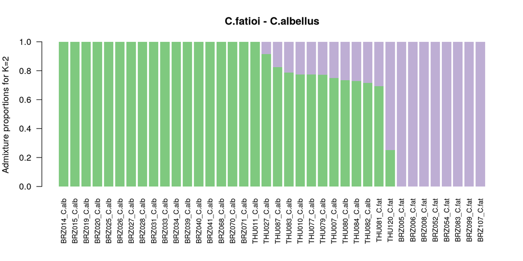

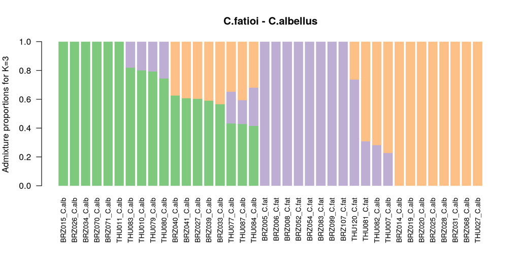

### C.acrinasus - C.fatioi - C.steinmanni

We exclude C.profundus because it seems to be a clearly cluster itself.

#### Removing species with less than 10 individuals/samples

Additionally, keep only those species that are present in lakes Brienz and Thun.

```r
poptable <- read.table('~/cophyhopa/data/popmap.txt',
                       col.names = c('sample', 'group', 'pop', 'lake'))

poptable <- poptable[-which(poptable[,3] == "C.alpinus"), ]
poptable <- poptable[-which(poptable[,3] == "C.alpinus/C.steinmanni"), ]
poptable <- poptable[-which(poptable[,3] == "C.brienzii"), ]
poptable <- poptable[-which(poptable[,3] == "C.fatioi/C.albellus"), ]
poptable <- poptable[-which(poptable[,3] == "D"), ]
poptable <- poptable[-which(poptable[,3] == "L"), ]
poptable <- poptable[-which(poptable[,3] == "P"), ]
poptable <- poptable[-which(poptable[,3] == "C.duplex"), ]
poptable <- poptable[-which(poptable[,3] == "C.heglingus"), ]
poptable <- poptable[-which(poptable[,3] == "C.zuerichensis"), ]
poptable <- poptable[-which(poptable[,3] == "C.confusus"), ]
poptable <- poptable[-which(poptable[,3] == "C.brienzii/C.fatioi"), ]

poptable <- poptable[-which(poptable[,3] == "C.profundus"), ]
poptable <- poptable[-which(poptable[,3] == "C.albellus"), ]

write.table(poptable[,1], file = '~/cophyhopa/results/2022-05-09/admixture/BT_afs.txt', quote = FALSE,
            row.names = FALSE, col.names = FALSE)
```

#### Data selecting and filtering

```bash
VCF='/gata/mar/cophyhopa/results/2022-04-22/assem2_outfiles/assem2.vcf'
FILE=BT_afs
if [ ! -e $FILE.vcf.gz ]; then
   vcftools --vcf $VCF \
            --out dirty \
            --keep BT_afs.txt \
            --remove ~/cophyhopa/results/2022-05-04/TheWorst.txt \
            --recode \
            --recode-INFO-all
   vcftools --vcf dirty.recode.vcf \
            --out $FILE \
            --thin 500 \
            --remove-indels \
            --mac 2 \
            --max-alleles 2 \
            --max-meanDP 1000 \
            --max-missing-count 7 \
            --stdout \
            --recode --recode-INFO-all \
            | gzip > $FILE.vcf.gz
fi
if [ -e dirty.recode.vcf ]; then rm dirty.recode.vcf; fi

if [ ! -e chromMap.txt ]; then
   gunzip -c $FILE".vcf.gz" | \
   gawk '(/^[^#]/){
      A[$1] = 1
   }END{
      N = 1
      for (chr in A) {
         print chr "\t" N
         N = N + 1
      }
   }' > chromMap.txt
fi

vcftools --gzvcf $FILE".vcf.gz" \
         --plink --mac 2 --remove-indels --max-alleles 2 \
         --chrom-map chromMap.txt \
         --out $FILE

gawk -v OFS="\t" '{
   $1 = 1
   $2 = 1 ":" $4
   print $0
}' $FILE".map" > better.map
mv better.map $FILE.map

plink --file $FILE --make-bed --out $FILE --allow-no-sex --allow-extra-chr 0
```

#### Admixture analysis with variant K

We define the K parameter from 2 to 4, computing the cross-validation error. Then, we extract these values.

```bash
INPUT='/gata/mar/cophyhopa/results/2022-05-09/admixture/BT_afs.bed'

for K in 2 3 4; do
  if [ ! -e log${K}.BT_afs.out ]; then
    admixture --cv $INPUT $K | tee log${K}.BT_afs.out;
  fi
done
```

```bash
grep -h CV log*.BT_afs.out
```

```
## CV error (K=2): 0.60358
## CV error (K=3): 0.75099
## CV error (K=4): 0.88043
```

#### Plot Q estimates for K = 2, 3 and 4

We choose the K that has given a lower value of the cross-validation error. We add the sample names and display a barplot.

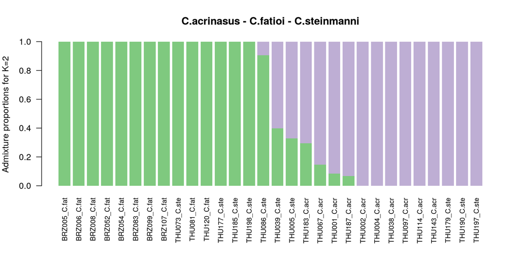

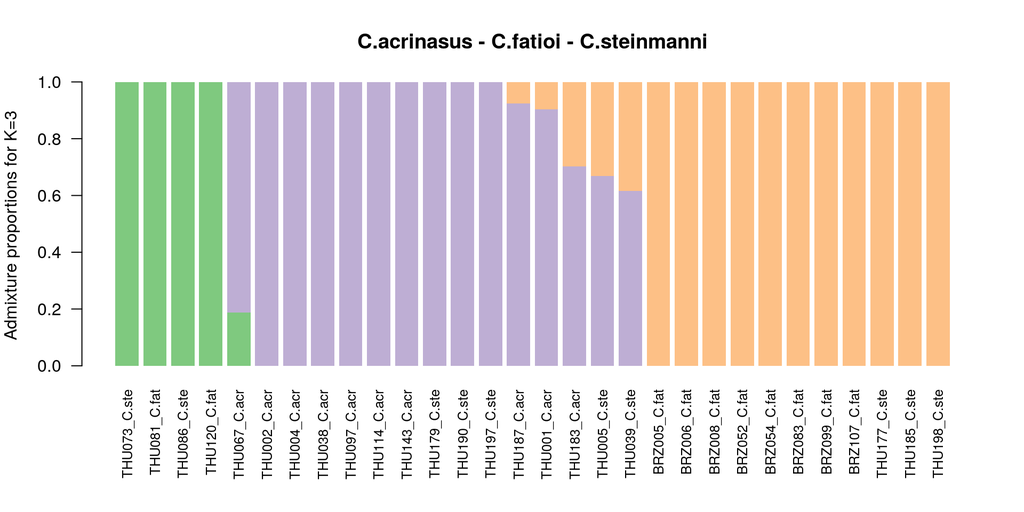

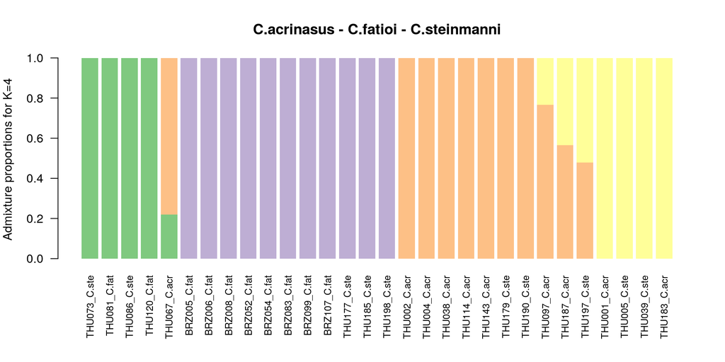

### C.acrinasus - C.fatioi

#### Removing species with less than 10 individuals/samples

Additionally, keep only those species that are present in lakes Brienz and Thun.

```r
poptable <- read.table('~/cophyhopa/data/popmap.txt',
                       col.names = c('sample', 'group', 'pop', 'lake'))

poptable <- poptable[-which(poptable[,3] == "C.alpinus"), ]
poptable <- poptable[-which(poptable[,3] == "C.alpinus/C.steinmanni"), ]
poptable <- poptable[-which(poptable[,3] == "C.brienzii"), ]
poptable <- poptable[-which(poptable[,3] == "C.fatioi/C.albellus"), ]
poptable <- poptable[-which(poptable[,3] == "D"), ]
poptable <- poptable[-which(poptable[,3] == "L"), ]
poptable <- poptable[-which(poptable[,3] == "P"), ]
poptable <- poptable[-which(poptable[,3] == "C.duplex"), ]
poptable <- poptable[-which(poptable[,3] == "C.heglingus"), ]
poptable <- poptable[-which(poptable[,3] == "C.zuerichensis"), ]
poptable <- poptable[-which(poptable[,3] == "C.confusus"), ]
poptable <- poptable[-which(poptable[,3] == "C.brienzii/C.fatioi"), ]

poptable <- poptable[-which(poptable[,3] == "C.steinmanni"), ]
poptable <- poptable[-which(poptable[,3] == "C.profundus"), ]
poptable <- poptable[-which(poptable[,3] == "C.albellus"), ]

write.table(poptable[,1], file = '~/cophyhopa/results/2022-05-09/admixture/BT_af.txt', quote = FALSE,
            row.names = FALSE, col.names = FALSE)
```

#### Data selecting and filtering

```bash
VCF='/gata/mar/cophyhopa/results/2022-04-22/assem2_outfiles/assem2.vcf'
FILE=BT_af
if [ ! -e $FILE.vcf.gz ]; then
   vcftools --vcf $VCF \
            --out dirty \
            --keep BT_af.txt \
            --remove ~/cophyhopa/results/2022-05-04/TheWorst.txt \
            --recode \
            --recode-INFO-all
   vcftools --vcf dirty.recode.vcf \
            --out $FILE \
            --thin 500 \
            --remove-indels \
            --mac 2 \
            --max-alleles 2 \
            --max-meanDP 1000 \
            --max-missing-count 7 \
            --stdout \
            --recode --recode-INFO-all \
            | gzip > $FILE.vcf.gz
fi
if [ -e dirty.recode.vcf ]; then rm dirty.recode.vcf; fi

if [ ! -e chromMap.txt ]; then
   gunzip -c $FILE".vcf.gz" | \
   gawk '(/^[^#]/){
      A[$1] = 1
   }END{
      N = 1
      for (chr in A) {
         print chr "\t" N
         N = N + 1
      }
   }' > chromMap.txt
fi

vcftools --gzvcf $FILE".vcf.gz" \
         --plink --mac 2 --remove-indels --max-alleles 2 \
         --chrom-map chromMap.txt \
         --out $FILE

gawk -v OFS="\t" '{
   $1 = 1
   $2 = 1 ":" $4
   print $0
}' $FILE".map" > better.map
mv better.map $FILE.map

plink --file $FILE --make-bed --out $FILE --allow-no-sex --allow-extra-chr 0
```

#### Admixture analysis with variant K

We define the K parameter from 2 to 3, computing the cross-validation error. Then, we extract these values.

```bash
INPUT='/gata/mar/cophyhopa/results/2022-05-09/admixture/BT_af.bed'

for K in 2 3; do
  if [ ! -e log${K}.BT_af.out ]; then
    admixture --cv $INPUT $K | tee log${K}.BT_af.out;
  fi
done
```

```bash
grep -h CV log*.BT_af.out
```

```
## CV error (K=2): 0.76311
## CV error (K=3): 1.09436
```

#### Plot Q estimates for K = 2 and 3

We choose the K that has given a lower value of the cross-validation error. We add the sample names and display a barplot.

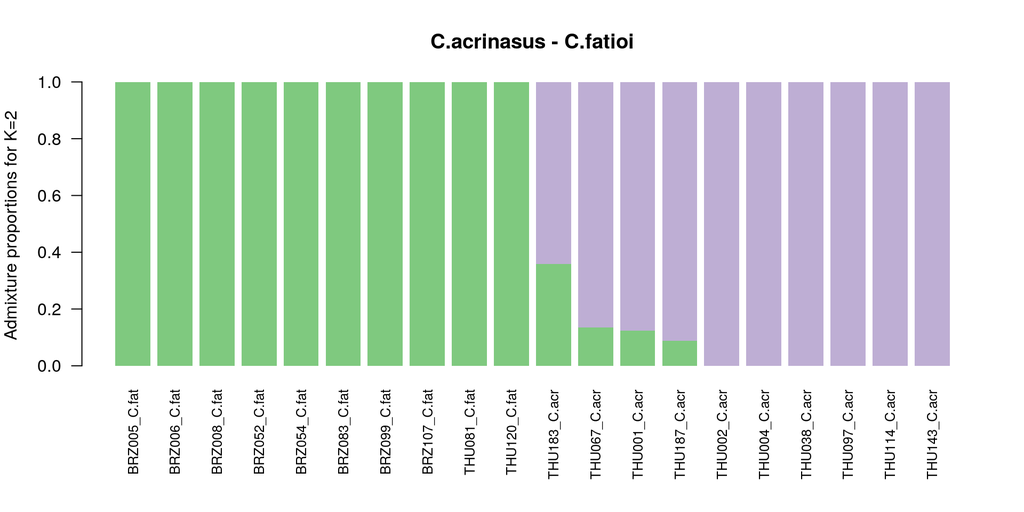

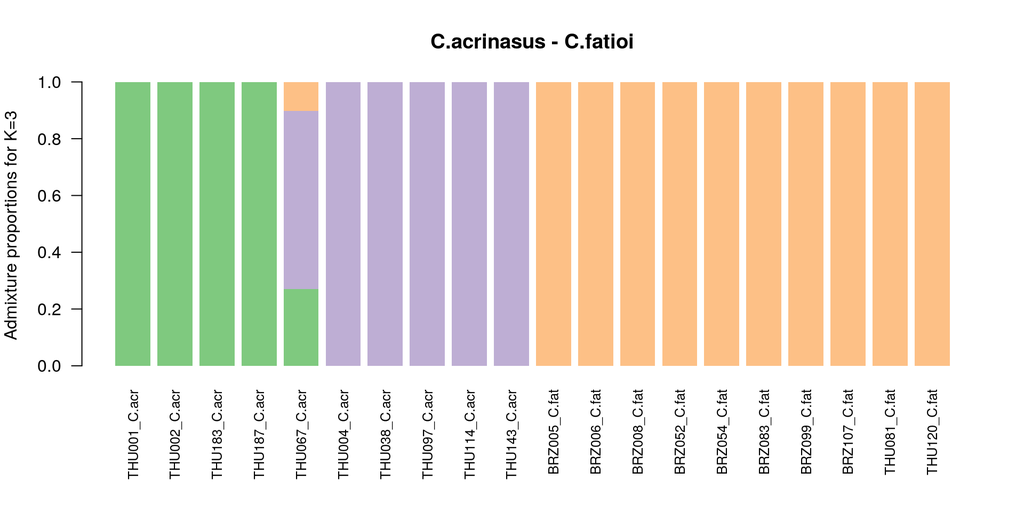

## Lakes Brienz, Thun and Bienne

### C.acrinasus - C.fatioi - C.albellus - C.profundus - C.steinmanni - C.confusus

We add C.confusus, the only species in lake Bienne.

#### Removing species with less than 10 individuals/samples

Additionally, keep only those species that are present in lakes Brienz and Thun.

```r
poptable <- read.table('~/cophyhopa/data/popmap.txt',
                       col.names = c('sample', 'group', 'pop', 'lake'))

poptable <- poptable[-which(poptable[,3] == "C.alpinus"), ]
poptable <- poptable[-which(poptable[,3] == "C.alpinus/C.steinmanni"), ]
poptable <- poptable[-which(poptable[,3] == "C.brienzii"), ]
poptable <- poptable[-which(poptable[,3] == "C.fatioi/C.albellus"), ]
poptable <- poptable[-which(poptable[,3] == "D"), ]
poptable <- poptable[-which(poptable[,3] == "L"), ]
poptable <- poptable[-which(poptable[,3] == "P"), ]
poptable <- poptable[-which(poptable[,3] == "C.duplex"), ]
poptable <- poptable[-which(poptable[,3] == "C.heglingus"), ]
poptable <- poptable[-which(poptable[,3] == "C.zuerichensis"), ]
poptable <- poptable[-which(poptable[,3] == "C.brienzii/C.fatioi"), ]

write.table(poptable[,1], file = '~/cophyhopa/results/2022-05-09/admixture/BTB_all.txt', quote = FALSE,
            row.names = FALSE, col.names = FALSE)
```

#### Data selecting and filtering

```bash
VCF='/gata/mar/cophyhopa/results/2022-04-22/assem2_outfiles/assem2.vcf'
FILE=BTB_all
if [ ! -e $FILE.vcf.gz ]; then
   vcftools --vcf $VCF \
            --out dirty \
            --keep BTB_all.txt \
            --remove ~/cophyhopa/results/2022-05-04/TheWorst.txt \
            --recode \
            --recode-INFO-all
   vcftools --vcf dirty.recode.vcf \
            --out $FILE \
            --thin 500 \
            --remove-indels \
            --mac 2 \
            --max-alleles 2 \
            --max-meanDP 1000 \
            --max-missing-count 7 \
            --stdout \
            --recode --recode-INFO-all \
            | gzip > $FILE.vcf.gz
fi
if [ -e dirty.recode.vcf ]; then rm dirty.recode.vcf; fi

if [ ! -e chromMap.txt ]; then
   gunzip -c $FILE".vcf.gz" | \
   gawk '(/^[^#]/){
      A[$1] = 1
   }END{
      N = 1
      for (chr in A) {
         print chr "\t" N
         N = N + 1
      }
   }' > chromMap.txt
fi

vcftools --gzvcf $FILE".vcf.gz" \
         --plink --mac 2 --remove-indels --max-alleles 2 \
         --chrom-map chromMap.txt \
         --out $FILE

gawk -v OFS="\t" '{
   $1 = 1
   $2 = 1 ":" $4
   print $0
}' $FILE".map" > better.map
mv better.map $FILE.map

plink --file $FILE --make-bed --out $FILE --allow-no-sex --allow-extra-chr 0
```

#### Admixture analysis with variant K

We define the K parameter from 4 to 6, computing the cross-validation error. Then, we extract these values.

```bash
INPUT='/gata/mar/cophyhopa/results/2022-05-09/admixture/BTB_all.bed'

for K in 4 5 6; do
  if [ ! -e log${K}.BTB_all.out ]; then
    admixture --cv $INPUT $K | tee log${K}.BTB_all.out;
  fi
done
```

```bash
grep -h CV log*.BTB_all.out
```

```
## CV error (K=4): 0.40809
## CV error (K=5): 0.42337
## CV error (K=6): 0.44290
```

#### Plot Q estimates for K = 4, 5 and 6

We choose the K that has given a lower value of the cross-validation error. We add the sample names and display a barplot

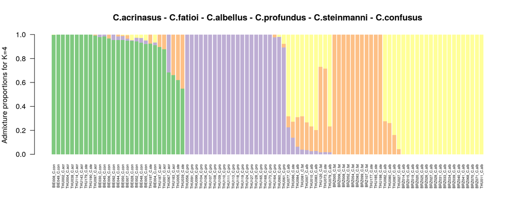

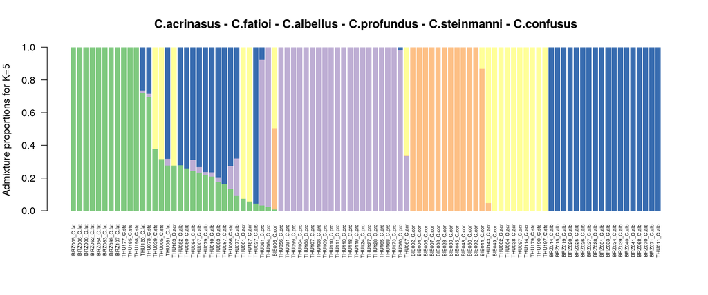

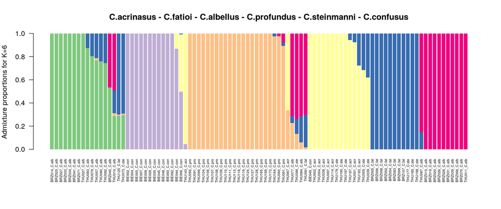

### C.acrinasus - C.fatioi - C.albellus - C.profundus - C.confusus

We add C.confusus, the only species in lake Bienne, and exclude C.steinmanni.

#### Removing species with less than 10 individuals/samples

Additionally, keep only those species that are present in lakes Brienz and Thun.

```r
poptable <- read.table('~/cophyhopa/data/popmap.txt',
                       col.names = c('sample', 'group', 'pop', 'lake'))

poptable <- poptable[-which(poptable[,3] == "C.alpinus"), ]
poptable <- poptable[-which(poptable[,3] == "C.alpinus/C.steinmanni"), ]
poptable <- poptable[-which(poptable[,3] == "C.brienzii"), ]
poptable <- poptable[-which(poptable[,3] == "C.fatioi/C.albellus"), ]
poptable <- poptable[-which(poptable[,3] == "D"), ]
poptable <- poptable[-which(poptable[,3] == "L"), ]
poptable <- poptable[-which(poptable[,3] == "P"), ]
poptable <- poptable[-which(poptable[,3] == "C.duplex"), ]
poptable <- poptable[-which(poptable[,3] == "C.heglingus"), ]
poptable <- poptable[-which(poptable[,3] == "C.zuerichensis"), ]
poptable <- poptable[-which(poptable[,3] == "C.brienzii/C.fatioi"), ]

poptable <- poptable[-which(poptable[,3] == "C.steinmanni"), ]


write.table(poptable[,1], file = '~/cophyhopa/results/2022-05-09/admixture/BTB_afapc.txt', quote = FALSE,
            row.names = FALSE, col.names = FALSE)
```

#### Data selecting and filtering

```bash
VCF='/gata/mar/cophyhopa/results/2022-04-22/assem2_outfiles/assem2.vcf'
FILE=BTB_afapc
if [ ! -e $FILE.vcf.gz ]; then
   vcftools --vcf $VCF \
            --out dirty \
            --keep BTB_afapc.txt \
            --remove ~/cophyhopa/results/2022-05-04/TheWorst.txt \
            --recode \
            --recode-INFO-all
   vcftools --vcf dirty.recode.vcf \
            --out $FILE \
            --thin 500 \
            --remove-indels \
            --mac 2 \
            --max-alleles 2 \
            --max-meanDP 1000 \
            --max-missing-count 7 \
            --stdout \
            --recode --recode-INFO-all \
            | gzip > $FILE.vcf.gz
fi
if [ -e dirty.recode.vcf ]; then rm dirty.recode.vcf; fi

if [ ! -e chromMap.txt ]; then
   gunzip -c $FILE".vcf.gz" | \
   gawk '(/^[^#]/){
      A[$1] = 1
   }END{
      N = 1
      for (chr in A) {
         print chr "\t" N
         N = N + 1
      }
   }' > chromMap.txt
fi

vcftools --gzvcf $FILE".vcf.gz" \
         --plink --mac 2 --remove-indels --max-alleles 2 \
         --chrom-map chromMap.txt \
         --out $FILE

gawk -v OFS="\t" '{
   $1 = 1
   $2 = 1 ":" $4
   print $0
}' $FILE".map" > better.map
mv better.map $FILE.map

plink --file $FILE --make-bed --out $FILE --allow-no-sex --allow-extra-chr 0
```

#### Admixture analysis with variant K

```bash
INPUT='/gata/mar/cophyhopa/results/2022-05-09/admixture/BTB_afapc.bed'

for K in 4 5 6; do
  if [ ! -e log${K}.BTB_afapc.out ]; then
    admixture --cv $INPUT $K | tee log${K}.BTB_afapc.out;
  fi
done
```

```bash
grep -h CV log*.BTB_afapc.out
```

```
## CV error (K=4): 0.42867
## CV error (K=5): 0.44970
## CV error (K=6): 0.47040
```

#### Plot Q estimates for K = 4, 5 and 6

We choose the K that has given a lower value of the cross-validation error. We add the sample names and display a barplot

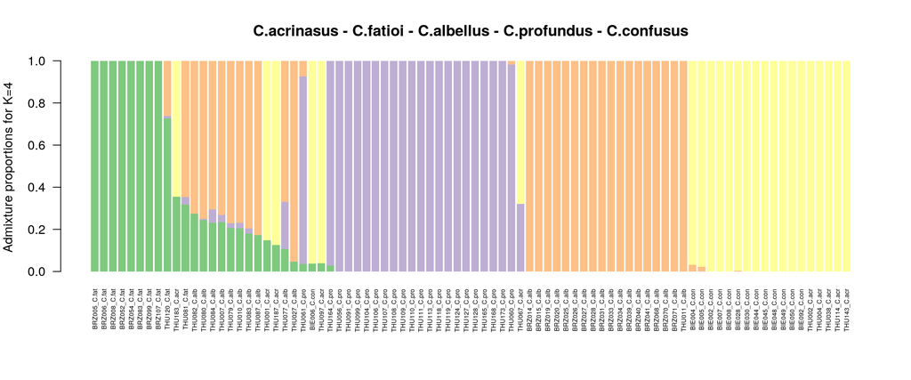

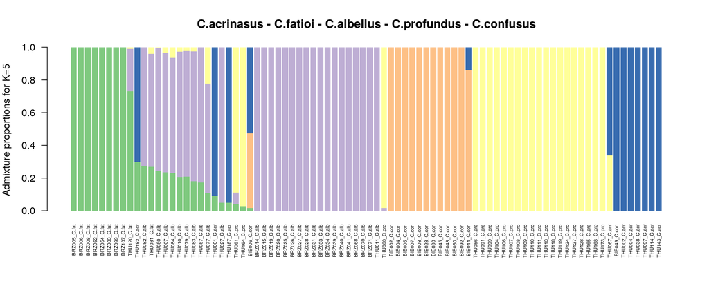

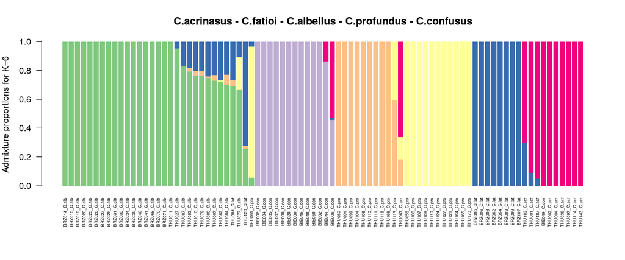